# Compute Rate v/s Number of Instructions

Anshul Gupta

12/07/2014

```r
setwd('~/git/ScalaTrace-TI')
library(ggplot2)
dataset.tic.lu.B.8.comp.4b.I<-read.table("datasets/tic.lu.B.8.comp.4b.I", header=TRUE)
dataset.tic.lu.B.8.comp.4b.II<-read.table("datasets/tic.lu.B.8.comp.4b.II", header=TRUE)
dataset.tic.lu.B.8.comp.4b.III<-read.table("datasets/tic.lu.B.8.comp.4b.III", header=TRUE)
dataset.tic.lu.B.8.comp.4b.IV<-read.table("datasets/tic.lu.B.8.comp.4b.IV", header=TRUE)
dataset.tic.lu.B.8.comp.4b.V<-read.table("datasets/tic.lu.B.8.comp.4b.V", header=TRUE)
dataset.tic.lu.B.8.comp.4c.I<-read.table("datasets/tic.lu.B.8.comp.4c.I", header=TRUE)
dataset.tic.lu.B.8.comp.4c.II<-read.table("datasets/tic.lu.B.8.comp.4c.II", header=TRUE)
dataset.tic.lu.B.8.comp.4c.III<-read.table("datasets/tic.lu.B.8.comp.4c.III", header=TRUE)
dataset.tic.lu.B.8.comp.4c.IV<-read.table("datasets/tic.lu.B.8.comp.4c.IV", header=TRUE)
dataset.tic.lu.B.8.comp.4c.V<-read.table("datasets/tic.lu.B.8.comp.4c.V", header=TRUE)

dataset.tic.lu.B.16.comp.4b.I<-read.table("datasets/tic.lu.B.16.comp.4b.I", header=TRUE)
dataset.tic.lu.B.16.comp.4b.II<-read.table("datasets/tic.lu.B.16.comp.4b.II", header=TRUE)
dataset.tic.lu.B.16.comp.4b.III<-read.table("datasets/tic.lu.B.16.comp.4b.III", header=TRUE)
dataset.tic.lu.B.16.comp.4b.IV<-read.table("datasets/tic.lu.B.16.comp.4b.IV", header=TRUE)
dataset.tic.lu.B.16.comp.4b.V<-read.table("datasets/tic.lu.B.16.comp.4b.V", header=TRUE)
dataset.tic.lu.B.16.comp.4c.I<-read.table("datasets/tic.lu.B.16.comp.4c.I", header=TRUE)
dataset.tic.lu.B.16.comp.4c.II<-read.table("datasets/tic.lu.B.16.comp.4c.II", header=TRUE)
dataset.tic.lu.B.16.comp.4c.III<-read.table("datasets/tic.lu.B.16.comp.4c.III", header=TRUE)
dataset.tic.lu.B.16.comp.4c.IV<-read.table("datasets/tic.lu.B.16.comp.4c.IV", header=TRUE)
dataset.tic.lu.B.16.comp.4c.V<-read.table("datasets/tic.lu.B.16.comp.4c.V", header=TRUE)

dataset.tic.lu.C.8.comp.4b.I<-read.table("datasets/tic.lu.C.8.comp.4b.I", header=TRUE)
dataset.tic.lu.C.8.comp.4b.II<-read.table("datasets/tic.lu.C.8.comp.4b.II", header=TRUE)
dataset.tic.lu.C.8.comp.4b.III<-read.table("datasets/tic.lu.C.8.comp.4b.III", header=TRUE)
dataset.tic.lu.C.8.comp.4b.IV<-read.table("datasets/tic.lu.C.8.comp.4b.IV", header=TRUE)
dataset.tic.lu.C.8.comp.4b.V<-read.table("datasets/tic.lu.C.8.comp.4b.V", header=TRUE)
dataset.tic.lu.C.8.comp.4c.I<-read.table("datasets/tic.lu.C.8.comp.4c.I", header=TRUE)
dataset.tic.lu.C.8.comp.4c.II<-read.table("datasets/tic.lu.C.8.comp.4c.II", header=TRUE)
dataset.tic.lu.C.8.comp.4c.III<-read.table("datasets/tic.lu.C.8.comp.4c.III", header=TRUE)
dataset.tic.lu.C.8.comp.4c.IV<-read.table("datasets/tic.lu.C.8.comp.4c.IV", header=TRUE)
dataset.tic.lu.C.8.comp.4c.V<-read.table("datasets/tic.lu.C.8.comp.4c.V", header=TRUE)

dataset.tic.lu.C.16.comp.4b.I<-read.table("datasets/tic.lu.C.16.comp.4b.I", header=TRUE)
dataset.tic.lu.C.16.comp.4b.II<-read.table("datasets/tic.lu.C.16.comp.4b.II", header=TRUE)
dataset.tic.lu.C.16.comp.4b.III<-read.table("datasets/tic.lu.C.16.comp.4b.III", header=TRUE)
dataset.tic.lu.C.16.comp.4b.IV<-read.table("datasets/tic.lu.C.16.comp.4b.IV", header=TRUE)
dataset.tic.lu.C.16.comp.4b.V<-read.table("datasets/tic.lu.C.16.comp.4b.V", header=TRUE)
dataset.tic.lu.C.16.comp.4c.I<-read.table("datasets/tic.lu.C.16.comp.4c.I", header=TRUE)
dataset.tic.lu.C.16.comp.4c.II<-read.table("datasets/tic.lu.C.16.comp.4c.II", header=TRUE)
dataset.tic.lu.C.16.comp.4c.III<-read.table("datasets/tic.lu.C.16.comp.4c.III", header=TRUE)
dataset.tic.lu.C.16.comp.4c.IV<-read.table("datasets/tic.lu.C.16.comp.4c.IV", header=TRUE)
dataset.tic.lu.C.16.comp.4c.V<-read.table("datasets/tic.lu.C.16.comp.4c.V", header=TRUE)
```

The variables are named as `d.<A>.<B>.4b.4c.<X>`,  
where `<X>` is the TIC dataset,  
`<A>` is the class,  
and `<B>` is the number of processes.  
Each `d.<A>.<B>.4b.4c.<X>` has 6 fields:

- eventID = Event ID
- opcode = Opcode of the event
- subblock = Subblock ID of the event
- events = Number of elements involved in the event
- COMP.4b.avg = Average of COMP 4b
- COMP.4c.avg = Average of COMP 4c

```r
d.B.8.4b.4c.I<-cbind(dataset.tic.lu.B.8.comp.4b.I[,1:4], dataset.tic.lu.B.8.comp.4b.I$avg/1e6, dataset.tic.lu.B.8.comp.4c.I$avg*1e3)
d.B.8.4b.4c.II<-cbind(dataset.tic.lu.B.8.comp.4b.II[,1:4], dataset.tic.lu.B.8.comp.4b.II$avg/1e6, dataset.tic.lu.B.8.comp.4c.II$avg*1e3)
d.B.8.4b.4c.III<-cbind(dataset.tic.lu.B.8.comp.4b.III[,1:4], dataset.tic.lu.B.8.comp.4b.III$avg/1e6, dataset.tic.lu.B.8.comp.4c.III$avg*1e3)
d.B.8.4b.4c.IV<-cbind(dataset.tic.lu.B.8.comp.4b.IV[,1:4], dataset.tic.lu.B.8.comp.4b.IV$avg/1e6, dataset.tic.lu.B.8.comp.4c.IV$avg*1e3)
d.B.8.4b.4c.V<-cbind(dataset.tic.lu.B.8.comp.4b.V[,1:4], dataset.tic.lu.B.8.comp.4b.V$avg/1e6, dataset.tic.lu.B.8.comp.4c.V$avg*1e3)

colnames(d.B.8.4b.4c.I)[5:6]<-c("COMP.4b.avg", "COMP.4c.avg")
colnames(d.B.8.4b.4c.II)[5:6]<-c("COMP.4b.avg", "COMP.4c.avg")
colnames(d.B.8.4b.4c.III)[5:6]<-c("COMP.4b.avg", "COMP.4c.avg")
colnames(d.B.8.4b.4c.IV)[5:6]<-c("COMP.4b.avg", "COMP.4c.avg")
colnames(d.B.8.4b.4c.V)[5:6]<-c("COMP.4b.avg", "COMP.4c.avg")

d.B.16.4b.4c.I<-cbind(dataset.tic.lu.B.16.comp.4b.I[,1:4], dataset.tic.lu.B.16.comp.4b.I$avg/1e6, dataset.tic.lu.B.16.comp.4c.I$avg*1e3)
d.B.16.4b.4c.II<-cbind(dataset.tic.lu.B.16.comp.4b.II[,1:4], dataset.tic.lu.B.16.comp.4b.II$avg/1e6, dataset.tic.lu.B.16.comp.4c.II$avg*1e3)
d.B.16.4b.4c.III<-cbind(dataset.tic.lu.B.16.comp.4b.III[,1:4], dataset.tic.lu.B.16.comp.4b.III$avg/1e6, dataset.tic.lu.B.16.comp.4c.III$avg*1e3)
d.B.16.4b.4c.IV<-cbind(dataset.tic.lu.B.16.comp.4b.IV[,1:4], dataset.tic.lu.B.16.comp.4b.IV$avg/1e6, dataset.tic.lu.B.16.comp.4c.IV$avg*1e3)
d.B.16.4b.4c.V<-cbind(dataset.tic.lu.B.16.comp.4b.V[,1:4], dataset.tic.lu.B.16.comp.4b.V$avg/1e6, dataset.tic.lu.B.16.comp.4c.V$avg*1e3)

colnames(d.B.16.4b.4c.I)[5:6]<-c("COMP.4b.avg", "COMP.4c.avg")
colnames(d.B.16.4b.4c.II)[5:6]<-c("COMP.4b.avg", "COMP.4c.avg")
colnames(d.B.16.4b.4c.III)[5:6]<-c("COMP.4b.avg", "COMP.4c.avg")
colnames(d.B.16.4b.4c.IV)[5:6]<-c("COMP.4b.avg", "COMP.4c.avg")
colnames(d.B.16.4b.4c.V)[5:6]<-c("COMP.4b.avg", "COMP.4c.avg")

d.C.8.4b.4c.I<-cbind(dataset.tic.lu.C.8.comp.4b.I[,1:4], dataset.tic.lu.C.8.comp.4b.I$avg/1e6, dataset.tic.lu.C.8.comp.4c.I$avg*1e3)
d.C.8.4b.4c.II<-cbind(dataset.tic.lu.C.8.comp.4b.II[,1:4], dataset.tic.lu.C.8.comp.4b.II$avg/1e6, dataset.tic.lu.C.8.comp.4c.II$avg*1e3)
d.C.8.4b.4c.III<-cbind(dataset.tic.lu.C.8.comp.4b.III[,1:4], dataset.tic.lu.C.8.comp.4b.III$avg/1e6, dataset.tic.lu.C.8.comp.4c.III$avg*1e3)
d.C.8.4b.4c.IV<-cbind(dataset.tic.lu.C.8.comp.4b.IV[,1:4], dataset.tic.lu.C.8.comp.4b.IV$avg/1e6, dataset.tic.lu.C.8.comp.4c.IV$avg*1e3)
d.C.8.4b.4c.V<-cbind(dataset.tic.lu.C.8.comp.4b.V[,1:4], dataset.tic.lu.C.8.comp.4b.V$avg/1e6, dataset.tic.lu.C.8.comp.4c.V$avg*1e3)

colnames(d.C.8.4b.4c.I)[5:6]<-c("COMP.4b.avg", "COMP.4c.avg")
colnames(d.C.8.4b.4c.II)[5:6]<-c("COMP.4b.avg", "COMP.4c.avg")
colnames(d.C.8.4b.4c.III)[5:6]<-c("COMP.4b.avg", "COMP.4c.avg")
colnames(d.C.8.4b.4c.IV)[5:6]<-c("COMP.4b.avg", "COMP.4c.avg")
colnames(d.C.8.4b.4c.V)[5:6]<-c("COMP.4b.avg", "COMP.4c.avg")

d.C.16.4b.4c.I<-cbind(dataset.tic.lu.C.16.comp.4b.I[,1:4], dataset.tic.lu.C.16.comp.4b.I$avg/1e6, dataset.tic.lu.C.16.comp.4c.I$avg*1e3)
d.C.16.4b.4c.II<-cbind(dataset.tic.lu.C.16.comp.4b.II[,1:4], dataset.tic.lu.C.16.comp.4b.II$avg/1e6, dataset.tic.lu.C.16.comp.4c.II$avg*1e3)
d.C.16.4b.4c.III<-cbind(dataset.tic.lu.C.16.comp.4b.III[,1:4], dataset.tic.lu.C.16.comp.4b.III$avg/1e6, dataset.tic.lu.C.16.comp.4c.III$avg*1e3)
d.C.16.4b.4c.IV<-cbind(dataset.tic.lu.C.16.comp.4b.IV[,1:4], dataset.tic.lu.C.16.comp.4b.IV$avg/1e6, dataset.tic.lu.C.16.comp.4c.IV$avg*1e3)
d.C.16.4b.4c.V<-cbind(dataset.tic.lu.C.16.comp.4b.V[,1:4], dataset.tic.lu.C.16.comp.4b.V$avg/1e6, dataset.tic.lu.C.16.comp.4c.V$avg*1e3)

colnames(d.C.16.4b.4c.I)[5:6]<-c("COMP.4b.avg", "COMP.4c.avg")
colnames(d.C.16.4b.4c.II)[5:6]<-c("COMP.4b.avg", "COMP.4c.avg")
colnames(d.C.16.4b.4c.III)[5:6]<-c("COMP.4b.avg", "COMP.4c.avg")
colnames(d.C.16.4b.4c.IV)[5:6]<-c("COMP.4b.avg", "COMP.4c.avg")
colnames(d.C.16.4b.4c.V)[5:6]<-c("COMP.4b.avg", "COMP.4c.avg")
```

### Get the average instruction rate

Having COMP 4b averages and COMP 4c averages, instruction rate is calculated by:  
`instruction rate = mean(COMP.4c.average / COMP.4b.average)`

**Instruction Rate for dataset.tic.B.8**

```r
inst.rate.B.8<-c(mean(d.B.8.4b.4c.I$COMP.4c.avg/d.B.8.4b.4c.I$COMP.4b.avg),
     mean(d.B.8.4b.4c.II$COMP.4c.avg/d.B.8.4b.4c.II$COMP.4b.avg),
     mean(d.B.8.4b.4c.III$COMP.4c.avg/d.B.8.4b.4c.III$COMP.4b.avg),
     mean(d.B.8.4b.4c.IV$COMP.4c.avg/d.B.8.4b.4c.IV$COMP.4b.avg),
     mean(d.B.8.4b.4c.V$COMP.4c.avg/d.B.8.4b.4c.V$COMP.4b.avg))

names(inst.rate.B.8)<-c('dataset1','dataset2','dataset3','dataset4','dataset5')
print(inst.rate.B.8)
```

```
##  dataset1  dataset2  dataset3  dataset4  dataset5
## 3.529e+09 3.546e+09 3.536e+09 3.542e+09 3.543e+09
```

**Instruction Rate for dataset.tic.B.16**

```r
inst.rate.B.16<-c(mean(d.B.16.4b.4c.I$COMP.4c.avg/d.B.16.4b.4c.I$COMP.4b.avg),
     mean(d.B.16.4b.4c.II$COMP.4c.avg/d.B.16.4b.4c.II$COMP.4b.avg),
     mean(d.B.16.4b.4c.III$COMP.4c.avg/d.B.16.4b.4c.III$COMP.4b.avg),
     mean(d.B.16.4b.4c.IV$COMP.4c.avg/d.B.16.4b.4c.IV$COMP.4b.avg),
     mean(d.B.16.4b.4c.V$COMP.4c.avg/d.B.16.4b.4c.V$COMP.4b.avg))

names(inst.rate.B.16)<-c('dataset1','dataset2','dataset3','dataset4','dataset5')
print(inst.rate.B.16)
```

```
##  dataset1  dataset2  dataset3  dataset4  dataset5
## 3.412e+09 3.412e+09 3.402e+09 3.415e+09 3.427e+09
```

**Instruction Rate for dataset.tic.C.8**

```r
inst.rate.C.8<-c(mean(d.C.8.4b.4c.I$COMP.4c.avg/d.C.8.4b.4c.I$COMP.4b.avg),
     mean(d.C.8.4b.4c.II$COMP.4c.avg/d.C.8.4b.4c.II$COMP.4b.avg),
     mean(d.C.8.4b.4c.III$COMP.4c.avg/d.C.8.4b.4c.III$COMP.4b.avg),
     mean(d.C.8.4b.4c.IV$COMP.4c.avg/d.C.8.4b.4c.IV$COMP.4b.avg),
     mean(d.C.8.4b.4c.V$COMP.4c.avg/d.C.8.4b.4c.V$COMP.4b.avg))

names(inst.rate.C.8)<-c('dataset1','dataset2','dataset3','dataset4','dataset5')
print(inst.rate.C.8)
```

```
##  dataset1  dataset2  dataset3  dataset4  dataset5
## 3.466e+09 3.466e+09 3.471e+09 3.484e+09 3.469e+09
```

**Instruction Rate for dataset.tic.C.16**

```r
inst.rate.C.16<-c(mean(d.C.16.4b.4c.I$COMP.4c.avg/d.C.16.4b.4c.I$COMP.4b.avg),
     mean(d.C.16.4b.4c.II$COMP.4c.avg/d.C.16.4b.4c.II$COMP.4b.avg),
     mean(d.C.16.4b.4c.III$COMP.4c.avg/d.C.16.4b.4c.III$COMP.4b.avg),
     mean(d.C.16.4b.4c.IV$COMP.4c.avg/d.C.16.4b.4c.IV$COMP.4b.avg),
     mean(d.C.16.4b.4c.V$COMP.4c.avg/d.C.16.4b.4c.V$COMP.4b.avg))

names(inst.rate.C.16)<-c('dataset1','dataset2','dataset3','dataset4','dataset5')
print(inst.rate.C.16)
```

```
##  dataset1  dataset2  dataset3  dataset4  dataset5
## 3.389e+09 3.416e+09 3.414e+09 3.419e+09 3.408e+09
```

**Dataset.tic.B.8.I**

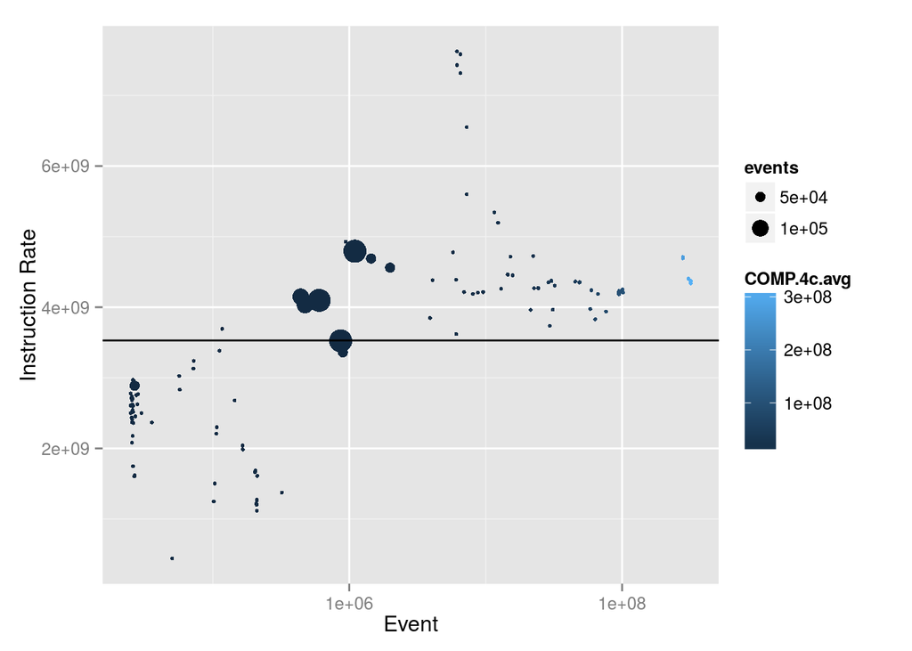

```r
ggplot(d.B.8.4b.4c.I, aes(x=COMP.4c.avg,
                      y=COMP.4c.avg/COMP.4b.avg,
                      color=COMP.4c.avg,
                      size=events)) +
  geom_point() + xlab("Event") + ylab("Instruction Rate") +
  geom_hline(yintercept=inst.rate.B.8[1]) + scale_x_log10()
```

**Dataset.tic.B.8.II**

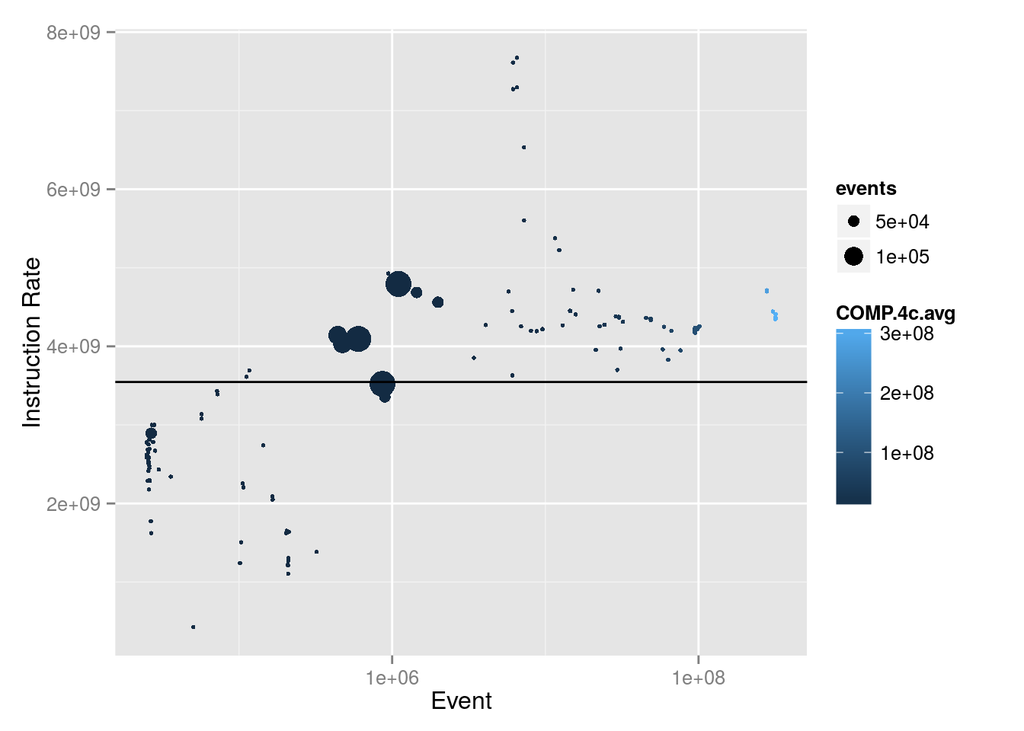

```r
ggplot(d.B.8.4b.4c.II, aes(x=COMP.4c.avg,
                      y=COMP.4c.avg/COMP.4b.avg,
                      color=COMP.4c.avg,
                      size=events)) +
  geom_point() + xlab("Event") + ylab("Instruction Rate") +
  geom_hline(yintercept=inst.rate.B.8[2]) + scale_x_log10()
```

**Dataset.tic.B.8.III**

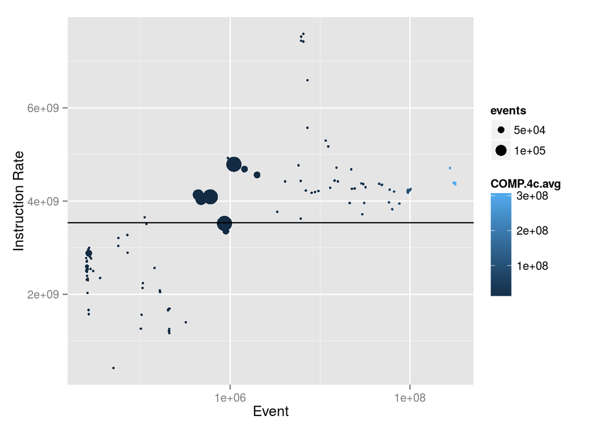

```r
ggplot(d.B.8.4b.4c.III, aes(x=COMP.4c.avg,
                      y=COMP.4c.avg/COMP.4b.avg,
                      color=COMP.4c.avg,
                      size=events)) +
  geom_point() + xlab("Event") + ylab("Instruction Rate") +
  geom_hline(yintercept=inst.rate.B.8[3]) + scale_x_log10()
```

**Dataset.tic.B.8.IV**

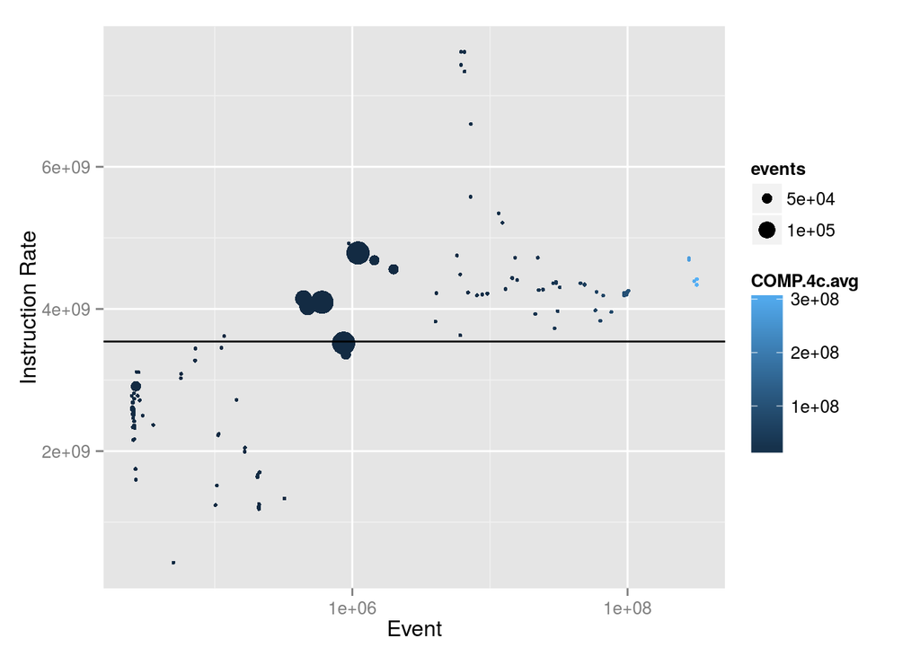

```r
ggplot(d.B.8.4b.4c.IV, aes(x=COMP.4c.avg,
                      y=COMP.4c.avg/COMP.4b.avg,
                      color=COMP.4c.avg,
                      size=events)) +
  geom_point() + xlab("Event") + ylab("Instruction Rate") +
  geom_hline(yintercept=inst.rate.B.8[4]) + scale_x_log10()
```

**Dataset.tic.B.8.V**

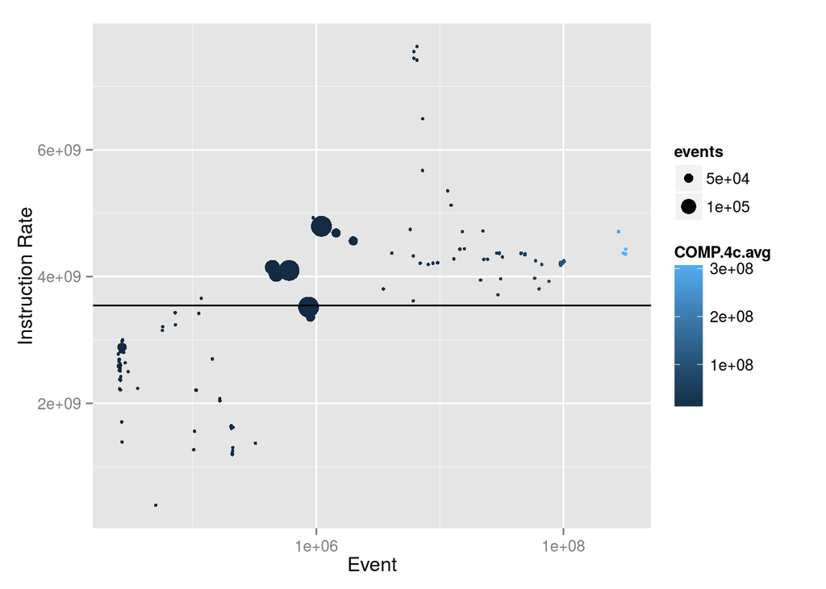

```r
ggplot(d.B.8.4b.4c.V, aes(x=COMP.4c.avg,
                      y=COMP.4c.avg/COMP.4b.avg,
                      color=COMP.4c.avg,
                      size=events)) +
  geom_point() + xlab("Event") + ylab("Instruction Rate") +
  geom_hline(yintercept=inst.rate.B.8[5]) + scale_x_log10()
```

**Dataset.tic.B.16.I**

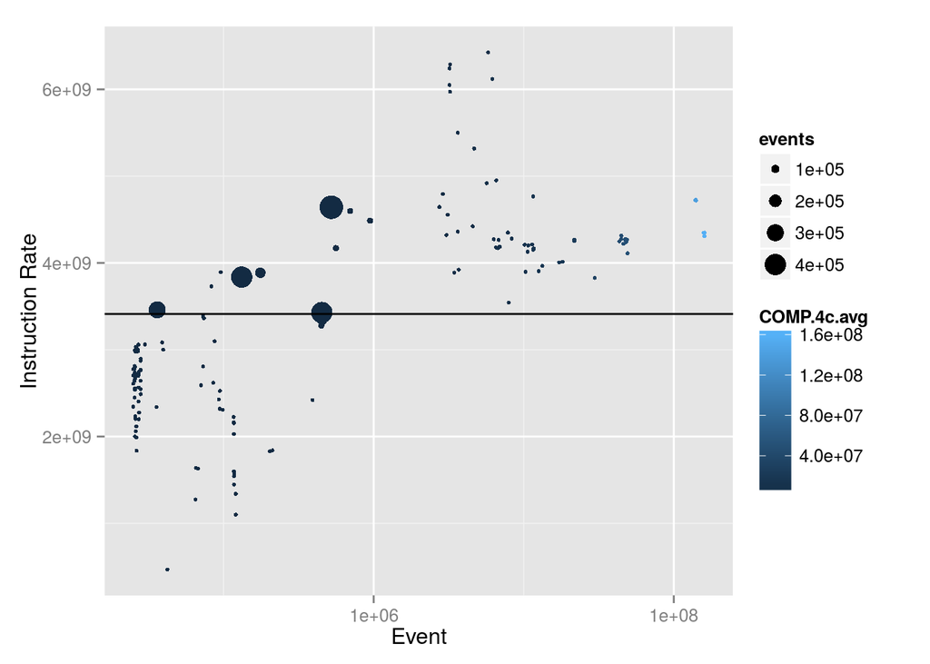

```r
ggplot(d.B.16.4b.4c.I, aes(x=COMP.4c.avg,
                      y=COMP.4c.avg/COMP.4b.avg,
                      color=COMP.4c.avg,
                      size=events)) +
  geom_point() + xlab("Event") + ylab("Instruction Rate") +
  geom_hline(yintercept=inst.rate.B.16[1]) + scale_x_log10()
```

**Dataset.tic.B.16.II**

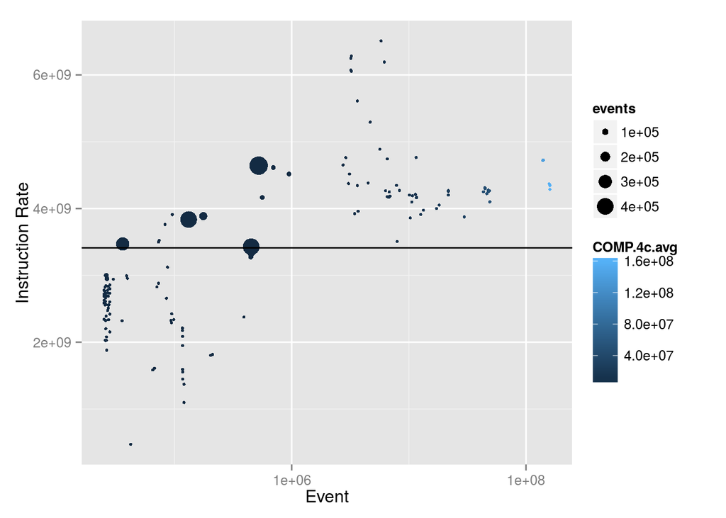

```r
ggplot(d.B.16.4b.4c.II, aes(x=COMP.4c.avg,
                      y=COMP.4c.avg/COMP.4b.avg,
                      color=COMP.4c.avg,
                      size=events)) +
  geom_point() + xlab("Event") + ylab("Instruction Rate") +
  geom_hline(yintercept=inst.rate.B.16[2]) + scale_x_log10()
```

**Dataset.tic.B.16.III**

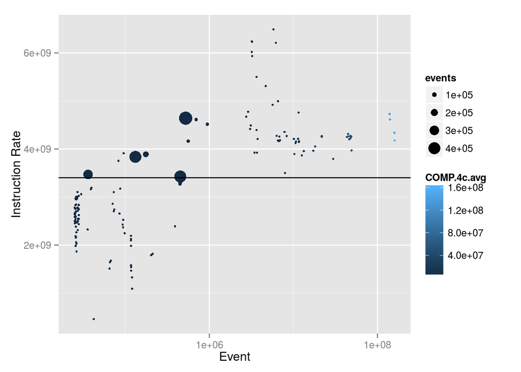

```r
ggplot(d.B.16.4b.4c.III, aes(x=COMP.4c.avg,
                      y=COMP.4c.avg/COMP.4b.avg,
                      color=COMP.4c.avg,
                      size=events)) +
  geom_point() + xlab("Event") + ylab("Instruction Rate") +
  geom_hline(yintercept=inst.rate.B.16[3]) + scale_x_log10()
```

**Dataset.tic.B.16.IV**

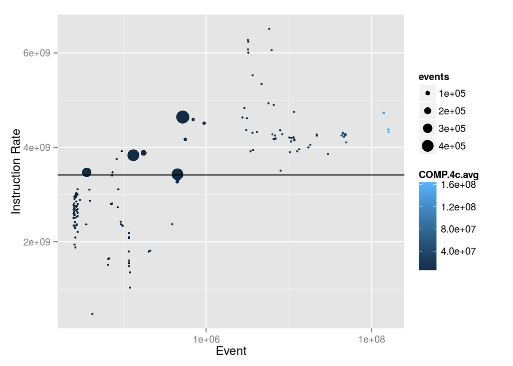

```r
ggplot(d.B.16.4b.4c.IV, aes(x=COMP.4c.avg,
                      y=COMP.4c.avg/COMP.4b.avg,
                      color=COMP.4c.avg,
                      size=events)) +
  geom_point() + xlab("Event") + ylab("Instruction Rate") +
  geom_hline(yintercept=inst.rate.B.16[4]) + scale_x_log10()
```

**Dataset.tic.B.16.V**

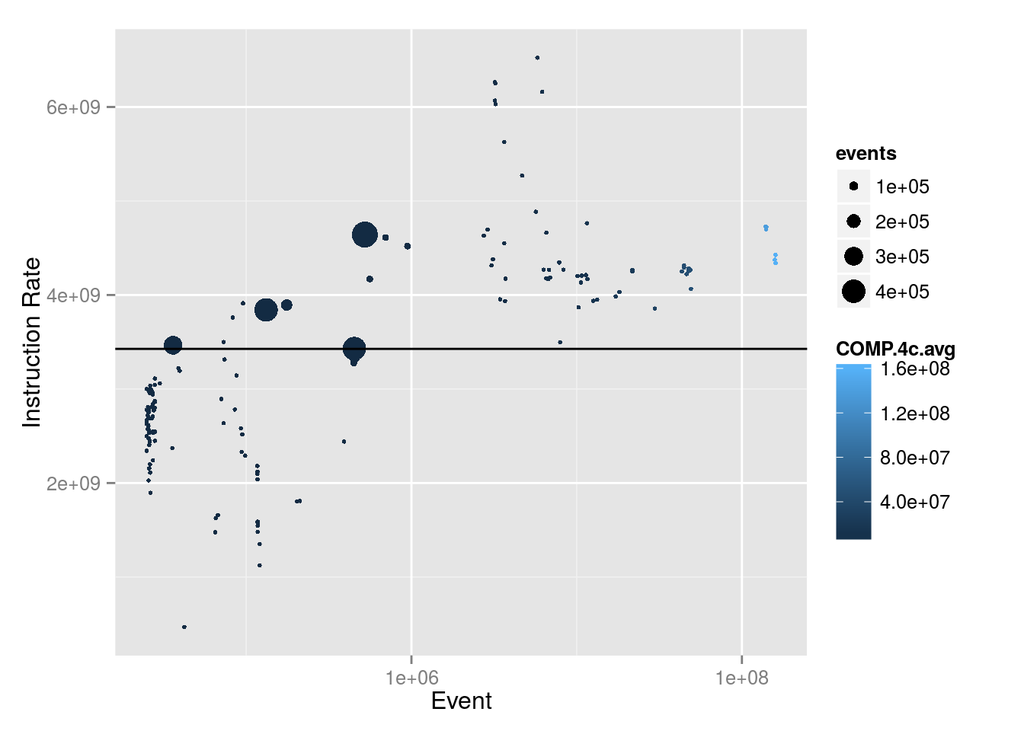

```r
ggplot(d.B.16.4b.4c.V, aes(x=COMP.4c.avg,
                      y=COMP.4c.avg/COMP.4b.avg,
                      color=COMP.4c.avg,
                      size=events)) +
  geom_point() + xlab("Event") + ylab("Instruction Rate") +
  geom_hline(yintercept=inst.rate.B.16[5]) + scale_x_log10()
```

**Dataset.tic.C.8.I**

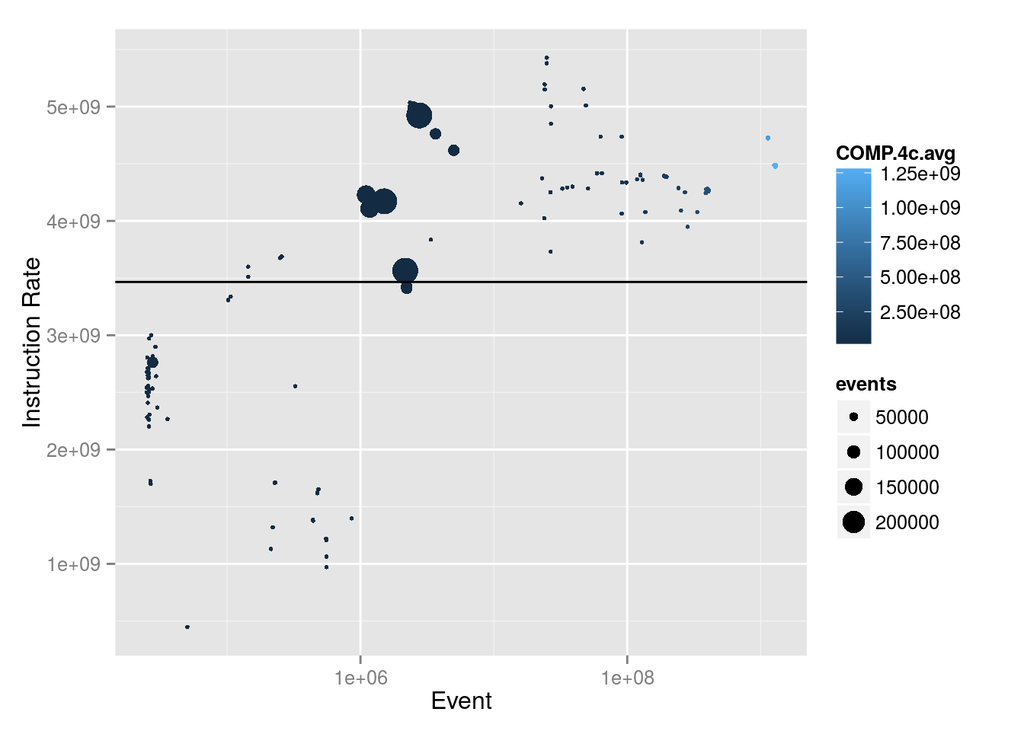

```r
ggplot(d.C.8.4b.4c.I, aes(x=COMP.4c.avg,
                      y=COMP.4c.avg/COMP.4b.avg,
                      color=COMP.4c.avg,
                      size=events)) +
  geom_point() + xlab("Event") + ylab("Instruction Rate") +
  geom_hline(yintercept=inst.rate.C.8[1]) + scale_x_log10()
```

**Dataset.tic.C.8.II**

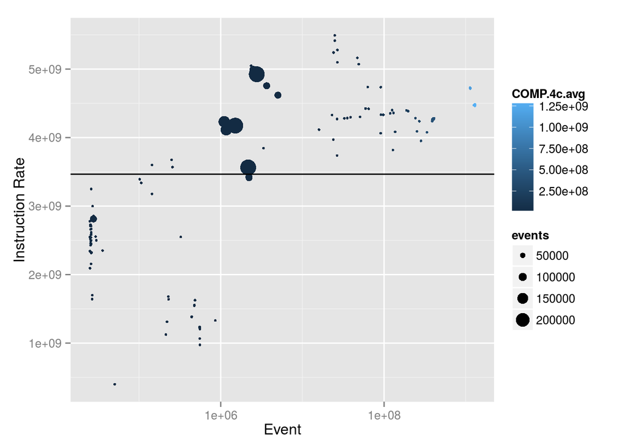

```r
ggplot(d.C.8.4b.4c.II, aes(x=COMP.4c.avg,
                      y=COMP.4c.avg/COMP.4b.avg,
                      color=COMP.4c.avg,
                      size=events)) +
  geom_point() + xlab("Event") + ylab("Instruction Rate") +
  geom_hline(yintercept=inst.rate.C.8[2]) + scale_x_log10()
```

**Dataset.tic.C.8.III**

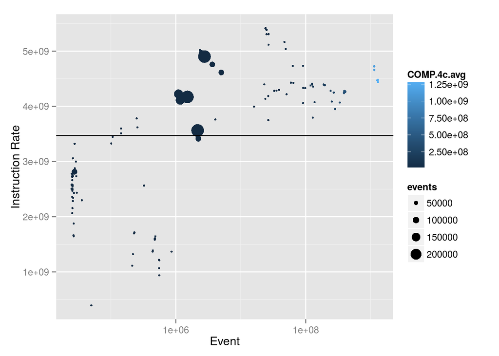

```r
ggplot(d.C.8.4b.4c.III, aes(x=COMP.4c.avg,
                      y=COMP.4c.avg/COMP.4b.avg,
                      color=COMP.4c.avg,
                      size=events)) +
  geom_point() + xlab("Event") + ylab("Instruction Rate") +
  geom_hline(yintercept=inst.rate.C.8[3]) + scale_x_log10()
```

**Dataset.tic.C.8.IV**

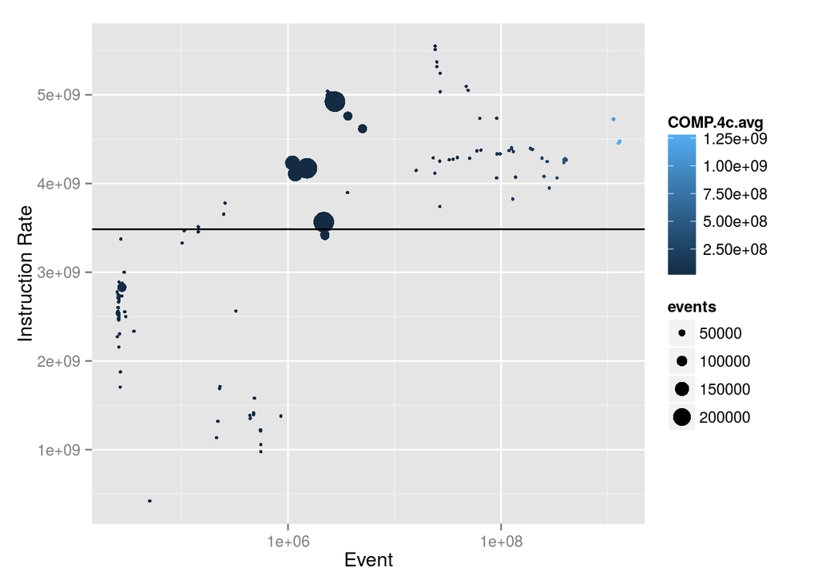

```r
ggplot(d.C.8.4b.4c.IV, aes(x=COMP.4c.avg,
                      y=COMP.4c.avg/COMP.4b.avg,
                      color=COMP.4c.avg,
                      size=events)) +
  geom_point() + xlab("Event") + ylab("Instruction Rate") +
  geom_hline(yintercept=inst.rate.C.8[4]) + scale_x_log10()
```

**Dataset.tic.C.8.V**

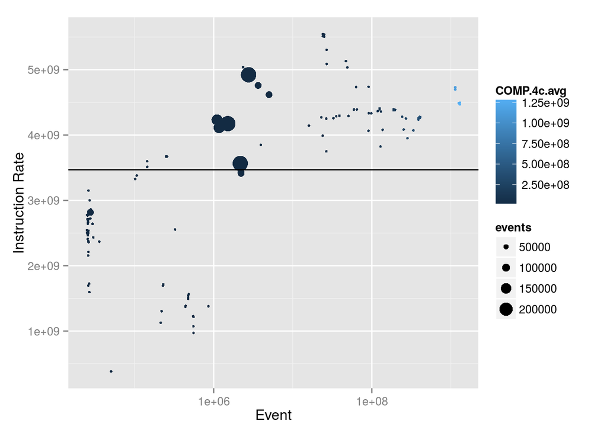

```r
ggplot(d.C.8.4b.4c.V, aes(x=COMP.4c.avg,
                      y=COMP.4c.avg/COMP.4b.avg,
                      color=COMP.4c.avg,
                      size=events)) +
  geom_point() + xlab("Event") + ylab("Instruction Rate") +
  geom_hline(yintercept=inst.rate.C.8[5]) + scale_x_log10()
```

**Dataset.tic.C.16.I**

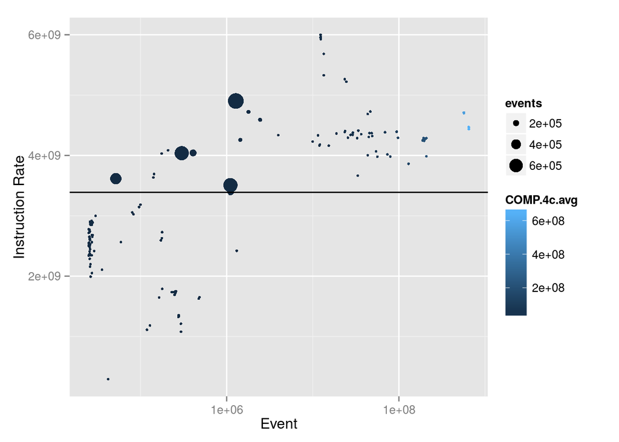

```r
ggplot(d.C.16.4b.4c.I, aes(x=COMP.4c.avg,
                      y=COMP.4c.avg/COMP.4b.avg,
                      color=COMP.4c.avg,
                      size=events)) +
  geom_point() + xlab("Event") + ylab("Instruction Rate") +
  geom_hline(yintercept=inst.rate.C.16[1]) + scale_x_log10()
```

**Dataset.tic.C.16.II**

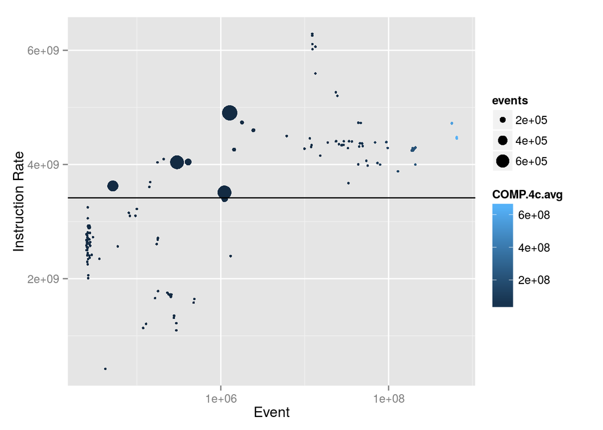

```r
ggplot(d.C.16.4b.4c.II, aes(x=COMP.4c.avg,
                      y=COMP.4c.avg/COMP.4b.avg,
                      color=COMP.4c.avg,
                      size=events)) +
  geom_point() + xlab("Event") + ylab("Instruction Rate") +
  geom_hline(yintercept=inst.rate.C.16[2]) + scale_x_log10()
```

**Dataset.tic.C.16.III**

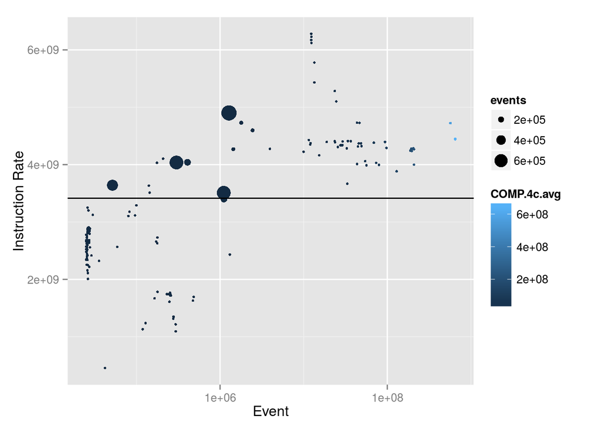

```r
ggplot(d.C.16.4b.4c.III, aes(x=COMP.4c.avg,
                      y=COMP.4c.avg/COMP.4b.avg,
                      color=COMP.4c.avg,
                      size=events)) +
  geom_point() + xlab("Event") + ylab("Instruction Rate") +
  geom_hline(yintercept=inst.rate.C.16[3]) + scale_x_log10()
```

**Dataset.tic.C.16.IV**

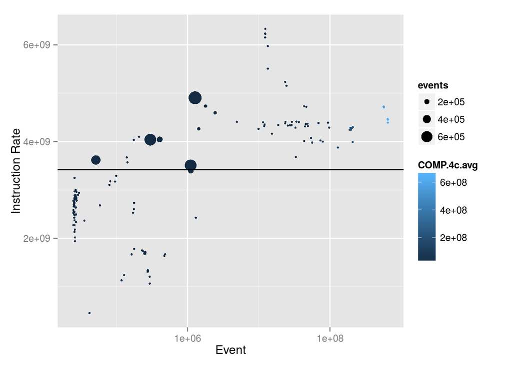

```r
ggplot(d.C.16.4b.4c.IV, aes(x=COMP.4c.avg,
                      y=COMP.4c.avg/COMP.4b.avg,
                      color=COMP.4c.avg,
                      size=events)) +
  geom_point() + xlab("Event") + ylab("Instruction Rate") +
  geom_hline(yintercept=inst.rate.C.16[4]) + scale_x_log10()
```

**Dataset.tic.C.16.V**

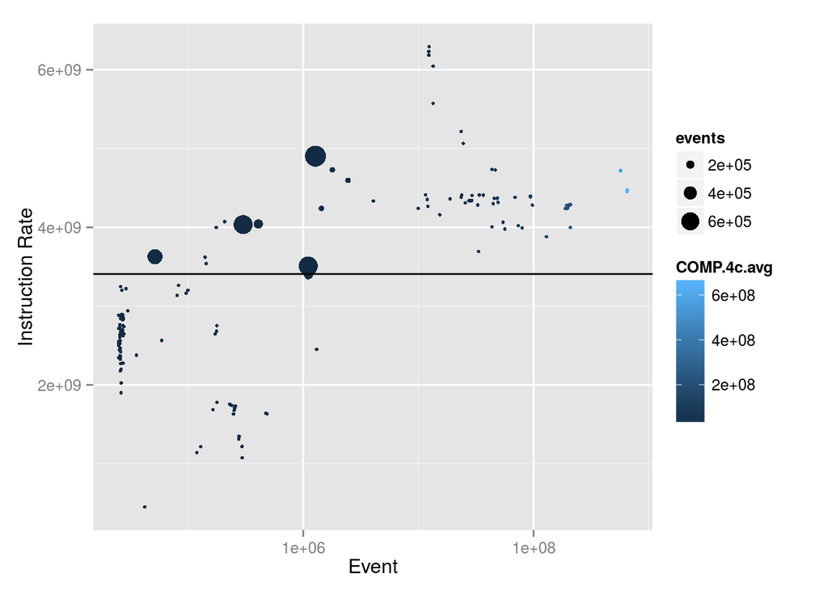

```r
ggplot(d.C.16.4b.4c.V, aes(x=COMP.4c.avg,
                      y=COMP.4c.avg/COMP.4b.avg,
                      color=COMP.4c.avg,
                      size=events)) +
  geom_point() + xlab("Event") + ylab("Instruction Rate") +
  geom_hline(yintercept=inst.rate.C.16[5]) + scale_x_log10()
```

```r
facet.frame.I<-rbind(data.frame(comp.4c.avg=d.B.8.4b.4c.I$COMP.4c.avg,
                                elements=d.B.8.4b.4c.I$events,
                                rate=d.B.8.4b.4c.I$COMP.4c.avg/d.B.8.4b.4c.I$COMP.4b.avg,
                                class="B-8"),
                     data.frame(comp.4c.avg=d.B.16.4b.4c.I$COMP.4c.avg,
                                elements=d.B.16.4b.4c.I$events,
                                rate=d.B.16.4b.4c.I$COMP.4c.avg/d.B.16.4b.4c.I$COMP.4b.avg,
                                class="B-16"),
                     data.frame(comp.4c.avg=d.C.8.4b.4c.I$COMP.4c.avg,
                                elements=d.C.8.4b.4c.I$events,
                                rate=d.C.8.4b.4c.I$COMP.4c.avg/d.C.8.4b.4c.I$COMP.4b.avg,
                                class="C-8"),
                     data.frame(comp.4c.avg=d.C.16.4b.4c.I$COMP.4c.avg,
                                elements=d.C.16.4b.4c.I$events,
                                rate=d.C.16.4b.4c.I$COMP.4c.avg/d.C.16.4b.4c.I$COMP.4b.avg,
                                class="C-16"))

facet.frame.II<-rbind(data.frame(comp.4c.avg=d.B.8.4b.4c.II$COMP.4c.avg,
                                 elements=d.B.8.4b.4c.II$events,
                                 rate=d.B.8.4b.4c.II$COMP.4c.avg/d.B.8.4b.4c.II$COMP.4b.avg,
                                 class="B-8"),
                      data.frame(comp.4c.avg=d.B.16.4b.4c.II$COMP.4c.avg,
                                 elements=d.B.16.4b.4c.II$events,
                                 rate=d.B.16.4b.4c.II$COMP.4c.avg/d.B.16.4b.4c.II$COMP.4b.avg,
                                 class="B-16"),
                      data.frame(comp.4c.avg=d.C.8.4b.4c.II$COMP.4c.avg,
                                 elements=d.C.8.4b.4c.II$events,
                                 rate=d.C.8.4b.4c.II$COMP.4c.avg/d.C.8.4b.4c.II$COMP.4b.avg,
                                 class="C-8"),
                      data.frame(comp.4c.avg=d.C.16.4b.4c.II$COMP.4c.avg,
                                 elements=d.C.16.4b.4c.II$events,
                                 rate=d.C.16.4b.4c.II$COMP.4c.avg/d.C.16.4b.4c.II$COMP.4b.avg,
                                 class="C-16"))

facet.frame.III<-rbind(data.frame(comp.4c.avg=d.B.8.4b.4c.III$COMP.4c.avg,
                                  elements=d.B.8.4b.4c.III$events,
                                  rate=d.B.8.4b.4c.III$COMP.4c.avg/d.B.8.4b.4c.III$COMP.4b.avg,
                                  class="B-8"),
                       data.frame(comp.4c.avg=d.B.16.4b.4c.III$COMP.4c.avg,
                                  elements=d.B.16.4b.4c.III$events,
                                  rate=d.B.16.4b.4c.III$COMP.4c.avg/d.B.16.4b.4c.III$COMP.4b.avg,
                                  class="B-16"),
                       data.frame(comp.4c.avg=d.C.8.4b.4c.III$COMP.4c.avg,
                                  elements=d.C.8.4b.4c.III$events,
                                  rate=d.C.8.4b.4c.III$COMP.4c.avg/d.C.8.4b.4c.III$COMP.4b.avg,
                                  class="C-8"),
                       data.frame(comp.4c.avg=d.C.16.4b.4c.III$COMP.4c.avg,
                                  elements=d.C.16.4b.4c.III$events,
                                  rate=d.C.16.4b.4c.III$COMP.4c.avg/d.C.16.4b.4c.III$COMP.4b.avg,
                                  class="C-16"))

facet.frame.IV<-rbind(data.frame(comp.4c.avg=d.B.8.4b.4c.IV$COMP.4c.avg,
                                 elements=d.B.8.4b.4c.IV$events,
                                 rate=d.B.8.4b.4c.IV$COMP.4c.avg/d.B.8.4b.4c.IV$COMP.4b.avg,
                                 class="B-8"),
                      data.frame(comp.4c.avg=d.B.16.4b.4c.IV$COMP.4c.avg,
                                 elements=d.B.16.4b.4c.IV$events,
                                 rate=d.B.16.4b.4c.IV$COMP.4c.avg/d.B.16.4b.4c.IV$COMP.4b.avg,
                                 class="B-16"),
                      data.frame(comp.4c.avg=d.C.8.4b.4c.IV$COMP.4c.avg,
                                 elements=d.C.8.4b.4c.IV$events,
                                 rate=d.C.8.4b.4c.IV$COMP.4c.avg/d.C.8.4b.4c.IV$COMP.4b.avg,
                                 class="C-8"),
                      data.frame(comp.4c.avg=d.C.16.4b.4c.IV$COMP.4c.avg,
                                 elements=d.C.16.4b.4c.IV$events,
                                 rate=d.C.16.4b.4c.IV$COMP.4c.avg/d.C.16.4b.4c.IV$COMP.4b.avg,
                                 class="C-16"))

facet.frame.V<-rbind(data.frame(comp.4c.avg=d.B.8.4b.4c.V$COMP.4c.avg,
                                elements=d.B.8.4b.4c.V$events,
                                rate=d.B.8.4b.4c.V$COMP.4c.avg/d.B.8.4b.4c.V$COMP.4b.avg,
                                class="B-8"),
                     data.frame(comp.4c.avg=d.B.16.4b.4c.V$COMP.4c.avg,
                                elements=d.B.16.4b.4c.V$events,
                                rate=d.B.16.4b.4c.V$COMP.4c.avg/d.B.16.4b.4c.V$COMP.4b.avg,
                                class="B-16"),
                     data.frame(comp.4c.avg=d.C.8.4b.4c.V$COMP.4c.avg,
                                elements=d.C.8.4b.4c.V$events,
                                rate=d.C.8.4b.4c.V$COMP.4c.avg/d.C.8.4b.4c.V$COMP.4b.avg,
                                class="C-8"),
                     data.frame(comp.4c.avg=d.C.16.4b.4c.V$COMP.4c.avg,
                                elements=d.C.16.4b.4c.V$events,
                                rate=d.C.16.4b.4c.V$COMP.4c.avg/d.C.16.4b.4c.V$COMP.4b.avg,
                                class="C-16"))
```

## Facet Plot for Dataset I

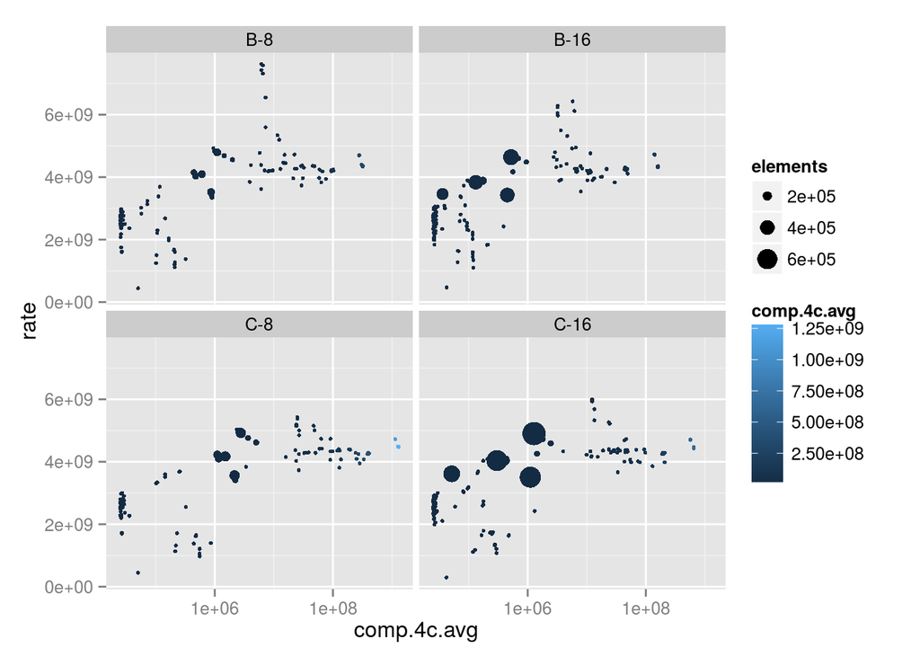

```r
ggplot(data=facet.frame.I, aes(x=comp.4c.avg, y=rate, color=comp.4c.avg, size=elements)) + geom_point() + facet_wrap(~ class) + scale_x_log10()
```

## Facet Plot for Dataset II

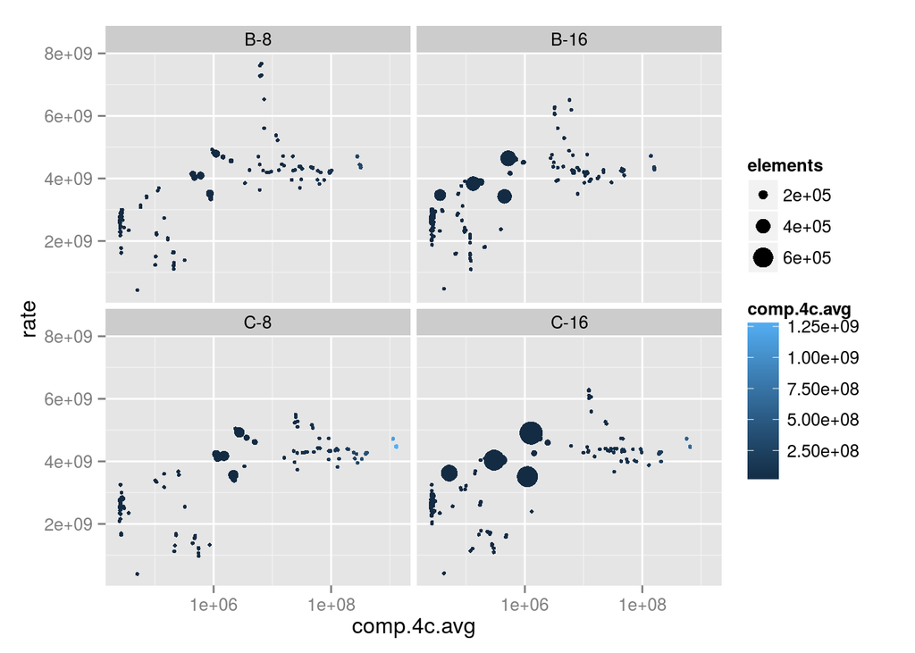

```r
ggplot(data=facet.frame.II, aes(x=comp.4c.avg, y=rate, color=comp.4c.avg, size=elements)) + geom_point() + facet_wrap(~ class) + scale_x_log10()
```

## Facet Plot for Dataset III

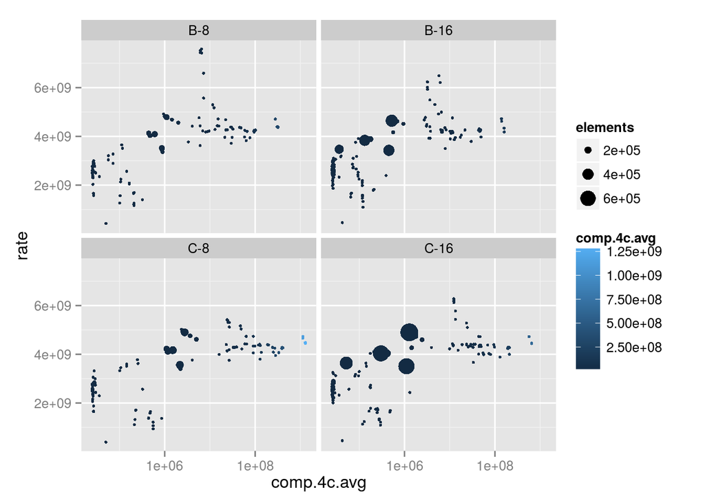

```r
ggplot(data=facet.frame.III, aes(x=comp.4c.avg, y=rate, color=comp.4c.avg, size=elements)) + geom_point() + facet_wrap(~ class) + scale_x_log10()
```

## Facet Plot for Dataset IV

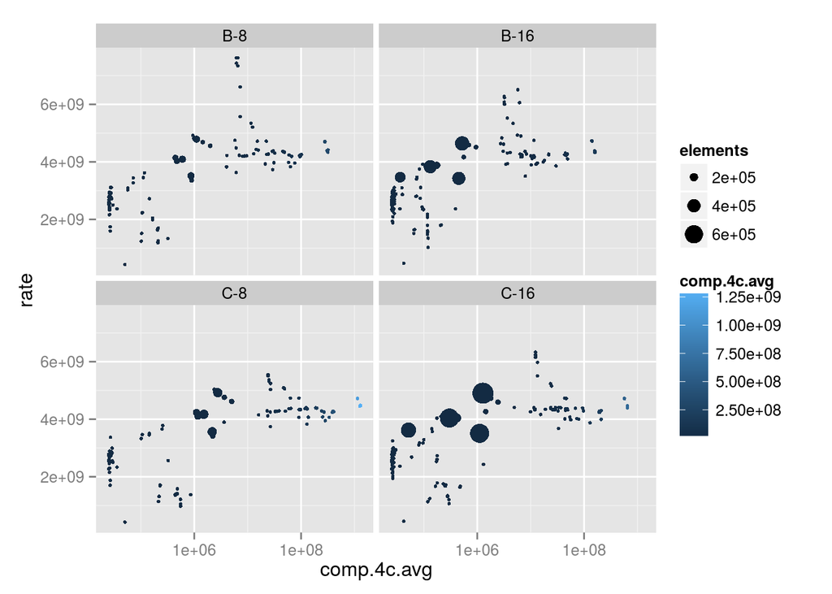

```r
ggplot(data=facet.frame.IV, aes(x=comp.4c.avg, y=rate, color=comp.4c.avg, size=elements)) + geom_point() + facet_wrap(~ class) + scale_x_log10()
```

## Facet Plot for Dataset V

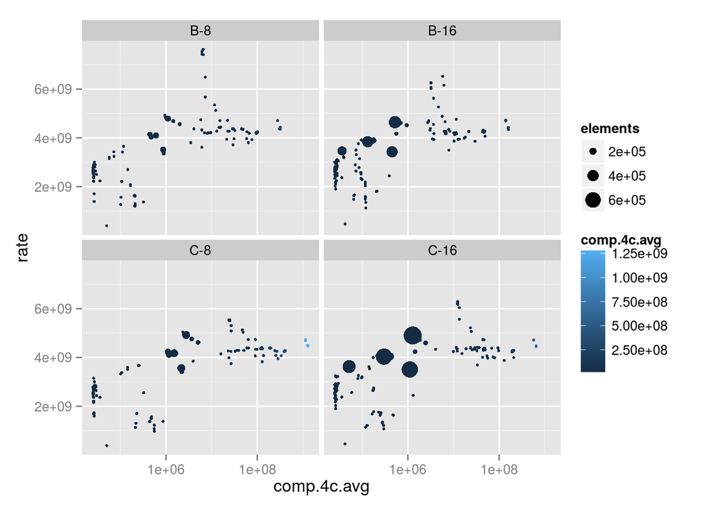

```r
ggplot(data=facet.frame.V, aes(x=comp.4c.avg, y=rate, color=comp.4c.avg, size=elements)) + geom_point() + facet_wrap(~ class) + scale_x_log10()
```